# Reading in the dataset

```
setwd("~/Desktop/CourseraDataScience/")
activity_data <- read.csv("activity 2.csv", header=TRUE, stringsAsFactors = FALSE)
```

Variables:

- steps: Number of steps taking in a 5-minute interval (missing values are coded as NA)
- date: The date on which the measurement was taken in YYYY-MM-DD format
- interval: Identifier for the 5-minute interval in which measurement was taken

# What is mean total number of steps taken per day?

Histogram of the total number of steps taken each day

```
activity_data$date <- as.Date(activity_data$date)
```

calculate the total number of steps per day

```
steps_per_day <- tapply(activity_data$steps, activity_data$date, sum)
```

plot the histogram

```
hist(steps_per_day, breaks = length(steps_per_day), xlab = "Steps per Day", main = "Histogram of the total number of steps taken each day")
```

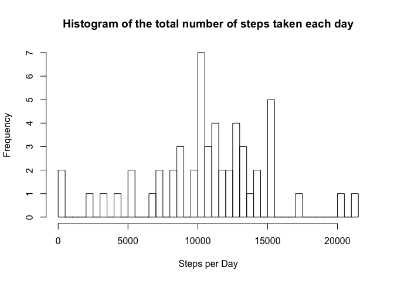

# Mean and median number of steps taken each day

```
mean(steps_per_day, na.rm = TRUE)

## [1] 10766.19
```

```
median(steps_per_day, na.rm = TRUE)

## [1] 10765
```

take out missing values in steps and the entire data frame

```
activity_full <- activity_data[!is.na(activity_data$steps), ]
```

# What is the average daily activity pattern?

averaged steps per interval

```
averageInterval <- tapply(activity_full$steps, activity_full$interval, mean)

plot(as.numeric(names(averageInterval)), averageInterval, type="l", xlab = "Intervals", ylab = "Average Steps")
```

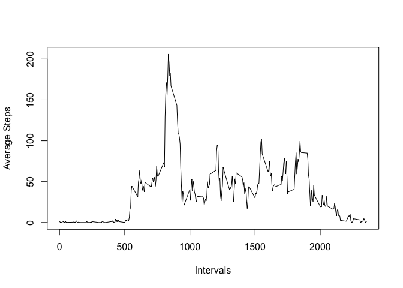

The 5-minute interval that, on average, contains the maximum number of steps

```
names(averageInterval[which.max(averageInterval)])

## [1] "835"
```

# Imputing missing values

replace missing values in variable steps with mean of all steps

```
activity_data[is.na(activity_data)] <- mean(activity_data$steps, na.rm = TRUE)
```

Histogram of the total number of steps taken each day after missing values are imputed

```
steps_per_day <- tapply(activity_data$steps, activity_data$date, sum)
hist(steps_per_day, breaks = length(steps_per_day), xlab = "Steps per Day", main = "Histogram of the total number of steps taken each day", sub = "with missing values imputed")
```

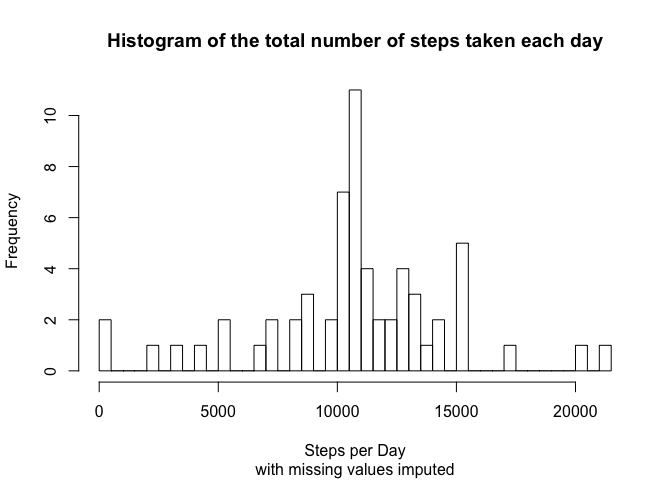

# Are there differences in activity patterns between weekdays and weekends? add a column to the data frame “activity_data” displaying the weekdays

```
activity_data$days <- weekdays(activity_data$date)
```

```
weekdays_data <- activity_data[(activity_data$days != "Saturday") & (activity_data$days != "Sunday"), ]
weekends_data <- activity_data[(activity_data$days == "Saturday") & (activity_data$days == "Saturday"), ]
```

take the mean of the steps per interval for each of the newly generated data frames

```
weekdays_ave <- tapply(weekdays_data$steps, weekdays_data$interval, mean)
weekends_ave <- tapply(weekends_data$steps, weekends_data$interval, mean)
```

```
par(mfrow=c(2,1))
plot(as.numeric(names(weekdays_ave)), weekdays_ave, type="l", xlab = "Intervals", ylab = "Average Steps", main = "Average Steps on Weekdays")
plot(as.numeric(names(weekends_ave)), weekends_ave, type="l", xlab = "Intervals", ylab = "Average Steps", main = "Average Steps on Weekends")
```

[figure not shown]